# Sparkify Small Dataset Analysis

A small subset (128MB) of the full dataset available (12GB) is analyzed below. A comprehensive univariate analysis of the data is performed.

```python
# import neccessary libraries and packages

import datetime

import numpy as np
import pandas as pd
import random

import matplotlib.pyplot as plt
%matplotlib inline
import seaborn as sns
sns.set_style("darkgrid")

from wordcloud import (
    WordCloud,
    ImageColorGenerator,
    )
import stylecloud

import pyspark
from pyspark import SparkContext
from pyspark import SparkConf

from pyspark.sql import SparkSession

from pyspark.sql.types import (
    StringType,
    IntegerType,
    DateType,
    TimestampType,
    )

from pyspark.sql.functions import (
    min as Fmin, max as Fmax,
    sum as Fsum, round as Fround,
    col, desc, asc,
    count, countDistinct,
    when, lit, lag, lead,
    isnull, isnan,
    from_unixtime, dayofmonth, month, hour,
    date_format,
    first, last, split,
    )

#import pyspark.sql.functions as F
```

```python
# create a Spark session

spark = SparkSession \
        .builder \
        .appName("Wrangling Mini Data") \
        .getOrCreate()

spark.sparkContext.setLogLevel("WARN")
```

## Load the Dataset

```python
path = "data/mini_sparkify_event_data.json"
df = spark.read.json(path)
```

## Analyze and Visualize the Data

```python
# count the number of rows
print("\nThere are {} records in the dataset.\n".format(df.count()))
# count the number of columns
print("The dataset has {} columns or features.\n".format(len(df.columns)))
```

```
There are 286500 records in the dataset.

The dataset has 18 columns or features.
```

```python
# peek at the data
df.show(2)
```

```
+----------------+---------+---------+------+-------------+--------+---------+-----+--------------------+------+--------+-------------+---------+---------+------+-------------+--------------------+------+
|          artist|     auth|firstName|gender|itemInSession|lastName|   length|level|            location|method|    page| registration|sessionId|     song|status|           ts|           userAgent|userId|
+----------------+---------+---------+------+-------------+--------+---------+-----+--------------------+------+--------+-------------+---------+---------+------+-------------+--------------------+------+
|  Martha Tilston|Logged In|    Colin|     M|           50| Freeman|277.89016| paid|     Bakersfield, CA|   PUT|NextSong|1538173362000|       29|Rockpools|   200|1538352117000|Mozilla/5.0 (Wind...|    30|
|Five Iron Frenzy|Logged In|    Micah|     M|           79|    Long|236.09424| free|Boston-Cambridge-...|   PUT|NextSong|1538331630000|        8|   Canada|   200|1538352180000|"Mozilla/5.0 (Win...|     9|
+----------------+---------+---------+------+-------------+--------+---------+-----+--------------------+------+--------+-------------+---------+---------+------+-------------+--------------------+------+
only showing top 2 rows
```

```python
# one more peek at the data
df.show(n=2, truncate=True, vertical=True)
```

```
-RECORD 0-----------------------------
 artist        | Martha Tilston
 auth          | Logged In
 firstName     | Colin
 gender        | M
 itemInSession | 50
 lastName      | Freeman
 length        | 277.89016
 level         | paid
 location      | Bakersfield, CA
 method        | PUT
 page          | NextSong
 registration  | 1538173362000
 sessionId     | 29
 song          | Rockpools
 status        | 200
 ts            | 1538352117000
 userAgent     | Mozilla/5.0 (Wind...
 userId        | 30
-RECORD 1-----------------------------
 artist        | Five Iron Frenzy
 auth          | Logged In
 firstName     | Micah
 gender        | M
 itemInSession | 79
 lastName      | Long
 length        | 236.09424
 level         | free
 location      | Boston-Cambridge-...
 method        | PUT
 page          | NextSong
 registration  | 1538331630000
 sessionId     | 8
 song          | Canada
 status        | 200
 ts            | 1538352180000
 userAgent     | "Mozilla/5.0 (Win...
 userId        | 9
only showing top 2 rows
```

### Print Schema and Investigate the Features

```python
# print and investigate the structure of the dataset
df.printSchema()
```

```
root
 |-- artist: string (nullable = true)
 |-- auth: string (nullable = true)
 |-- firstName: string (nullable = true)
 |-- gender: string (nullable = true)
 |-- itemInSession: long (nullable = true)
 |-- lastName: string (nullable = true)
 |-- length: double (nullable = true)
 |-- level: string (nullable = true)
 |-- location: string (nullable = true)
 |-- method: string (nullable = true)
 |-- page: string (nullable = true)
 |-- registration: long (nullable = true)
 |-- sessionId: long (nullable = true)
 |-- song: string (nullable = true)
 |-- status: long (nullable = true)
 |-- ts: long (nullable = true)
 |-- userAgent: string (nullable = true)
 |-- userId: string (nullable = true)
```

```python
# count null values in each column
df.select([count(when(isnan(c) | col(c).isNull(), c)) \
           .alias(c) for c in df.columns]) \
           .show(vertical=True)
```

```
[Stage 5:====>                                                    (1 + 11) / 12]
```

```
-RECORD 0--------------
 artist        | 58392
 auth          | 0
 firstName     | 8346
 gender        | 8346
 itemInSession | 0
 lastName      | 8346
 length        | 58392
 level         | 0
 location      | 8346
 method        | 0
 page          | 0
 registration  | 8346
 sessionId     | 0
 song          | 58392
 status        | 0
 ts            | 0
 userAgent     | 8346
 userId        | 0
```

```python
# count distinct entries in each column
df.select([countDistinct(c) \
           .alias(c) for c in df.columns]) \
           .show(vertical=True)
```

```
[Stage 7:>                                                        (0 + 12) / 12]
```

```
-RECORD 0---------------
 artist        | 17655
 auth          | 4
 firstName     | 189
 gender        | 2
 itemInSession | 1322
 lastName      | 173
 length        | 14865
 level         | 2
 location      | 114
 method        | 2
 page          | 22
 registration  | 225
 sessionId     | 2354
 song          | 58480
 status        | 3
 ts            | 277447
 userAgent     | 56
 userId        | 226
```

### Feature Descriptions and Data Types

A complete list of features, their data types, possible values and brief descriptions. The features are grouped on the type of information they contain: user, song or session information.

| Information | Column | DType | Brief Description |
| --- | --- | --- | --- |
| user-info | userId | string | unique identifier of the user |
| user-info | firstName | string | user's first name |
| user-info | lastName | string | user's last name |
| user-info | gender | string | user's gender, values: *F*, *M* |
| user-info | location | string | user's location |
| user-info | userAgent | string | information on the browser used by the user |
| user-info | level | string | subscription level, values: *free*, *paid* |
| user-info | registration | bigint | user's registration timestamp |
| song-info | artist | string | artist's name the song is by |
| song-info | song | string | song's name |
| song-info | length | double | song's length in seconds |
| log-info | auth | string | authentication: *Logged In*, *Logged Out*, *Cancelled*, *Guest* |
| log-info | itemInSession | bigint | number of logs in the session |
| log-info | method | string | HTTP request method, values: *GET*, *PUT* |
| log-info | page | string | type of action, 22 values: *Home*, *About*, *NextSong*, etc. |
| log-info | sessionId | bigint | session id |
| log-info | status | bigint | HTTP status code: values *200*, *404*, *307* |
| log-info | ts | bigint | timestamp of the log event |

### userId Column

```python
# the number of distinct userId stored in the dataset
df.select(countDistinct("userId")).show()
```

```
+----------------------+
|count(DISTINCT userId)|
+----------------------+
|                   226|
+----------------------+
```

```python
# count rows by userId
userId_counts = df.groupBy("userId").count().orderBy("userId")
userId_counts.show(8)
```

```
+------+-----+
|userId|count|
+------+-----+
|      | 8346|
|    10|  795|
|   100| 3214|
|100001|  187|
|100002|  218|
|100003|   78|
|100004| 1245|
|100005|  216|
+------+-----+
only showing top 8 rows
```

```python
# there are records with empty userId
userId_counts.show(1)
```

```
+------+-----+
|userId|count|
+------+-----+
|      | 8346|
+------+-----+
only showing top 1 row
```

```python
# investigate the entries with " " userId
blank_users = df.filter(df.userId == "")
blank_users.show(4)
```

```
+------+----------+---------+------+-------------+--------+------+-----+--------+------+-----+------------+---------+----+------+-------------+---------+------+
|artist|      auth|firstName|gender|itemInSession|lastName|length|level|location|method| page|registration|sessionId|song|status|           ts|userAgent|userId|
+------+----------+---------+------+-------------+--------+------+-----+--------+------+-----+------------+---------+----+------+-------------+---------+------+
|  null|Logged Out|     null|  null|          100|    null|  null| free|    null|   GET| Home|        null|        8|null|   200|1538355745000|     null|      |
|  null|Logged Out|     null|  null|          101|    null|  null| free|    null|   GET| Help|        null|        8|null|   200|1538355807000|     null|      |
|  null|Logged Out|     null|  null|          102|    null|  null| free|    null|   GET| Home|        null|        8|null|   200|1538355841000|     null|      |
|  null|Logged Out|     null|  null|          103|    null|  null| free|    null|   PUT|Login|        null|        8|null|   307|1538355842000|     null|      |
+------+----------+---------+------+-------------+--------+------+-----+--------+------+-----+------------+---------+----+------+-------------+---------+------+
only showing top 4 rows
```

```python
# count the unique entries in blank_users
blank_users.select([countDistinct(c) \
           .alias(c) for c in blank_users.columns]) \
           .show(vertical=True)
```

```
-RECORD 0-------------
 artist        | 0
 auth          | 2
 firstName     | 0
 gender        | 0
 itemInSession | 565
 lastName      | 0
 length        | 0
 level         | 2
 location      | 0
 method        | 2
 page          | 7
 registration  | 0
 sessionId     | 1629
 song          | 0
 status        | 3
 ts            | 8305
 userAgent     | 0
 userId        | 1
```

```python
# take a look at the empty userId that are paid users
blank_paid = blank_users.filter(blank_users.level == "paid")
blank_paid.show(4)
```

```
+------+----------+---------+------+-------------+--------+------+-----+--------+------+-----+------------+---------+----+------+-------------+---------+------+
|artist|      auth|firstName|gender|itemInSession|lastName|length|level|location|method| page|registration|sessionId|song|status|           ts|userAgent|userId|
+------+----------+---------+------+-------------+--------+------+-----+--------+------+-----+------------+---------+----+------+-------------+---------+------+
|  null|Logged Out|     null|  null|           49|    null|  null| paid|    null|   GET| Home|        null|      141|null|   200|1538381499000|     null|      |
|  null|Logged Out|     null|  null|           50|    null|  null| paid|    null|   PUT|Login|        null|      141|null|   307|1538381500000|     null|      |
|  null|Logged Out|     null|  null|           57|    null|  null| paid|    null|   GET| Home|        null|      141|null|   200|1538382349000|     null|      |
|  null|Logged Out|     null|  null|           58|    null|  null| paid|    null|   PUT|Login|        null|      141|null|   307|1538382350000|     null|      |
+------+----------+---------+------+-------------+--------+------+-----+--------+------+-----+------------+---------+----+------+-------------+---------+------+
only showing top 4 rows
```

```python
# the empty userId, paid are 'Logged Out' users
blank_paid.groupBy("auth").count().show()
```

```
+----------+-----+
|      auth|count|
+----------+-----+
|Logged Out| 5729|
+----------+-----+
```

```python
# take a look at the empty userId that are free users
blank_free = blank_users.filter(blank_users.level == "free")
blank_free.show(4)
```

```
+------+----------+---------+------+-------------+--------+------+-----+--------+------+-----+------------+---------+----+------+-------------+---------+------+
|artist|      auth|firstName|gender|itemInSession|lastName|length|level|location|method| page|registration|sessionId|song|status|           ts|userAgent|userId|
+------+----------+---------+------+-------------+--------+------+-----+--------+------+-----+------------+---------+----+------+-------------+---------+------+
|  null|Logged Out|     null|  null|          100|    null|  null| free|    null|   GET| Home|        null|        8|null|   200|1538355745000|     null|      |
|  null|Logged Out|     null|  null|          101|    null|  null| free|    null|   GET| Help|        null|        8|null|   200|1538355807000|     null|      |
|  null|Logged Out|     null|  null|          102|    null|  null| free|    null|   GET| Home|        null|        8|null|   200|1538355841000|     null|      |
|  null|Logged Out|     null|  null|          103|    null|  null| free|    null|   PUT|Login|        null|        8|null|   307|1538355842000|     null|      |
+------+----------+---------+------+-------------+--------+------+-----+--------+------+-----+------------+---------+----+------+-------------+---------+------+
only showing top 4 rows
```

```python
# most of the empty userId, that use free tier are also 'Logged Out' users
blank_free.groupBy("auth").count().show()
```

```
+----------+-----+
|      auth|count|
+----------+-----+
|Logged Out| 2520|
|     Guest|   97|
+----------+-----+
```

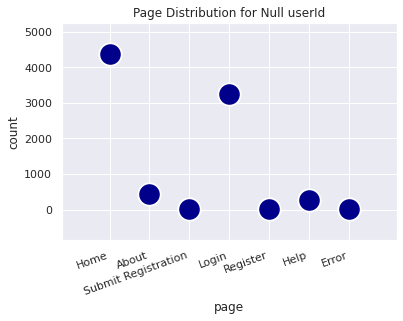

```python
# plot the page usage distribution for null userId

# create the count dataframe
blank_users_page = blank_users.groupby("page").count().toPandas()

# create the figure and title
sns.set(rc = {"figure.figsize":(6,4)})
sns.set(font_scale=1)

sns.scatterplot(x="page", y="count",
                data=blank_users_page,
                color="darkblue", s=500)

plt.title("Page Distribution for Null userId")
plt.xticks(rotation=20, horizontalalignment="right")

# pad margins so that markers don't get clipped by the axes
plt.margins(0.2)

plt.show()
```

There are 8346 rows where _userId_ is the empty string. Out of these, 5729 correspond to logged out paid users. The remaining 2617 records correspond to users that are not registered, that also logged out or they are logged in as _Guest_. We shall drop the records that have empty _userId_.

### firstName, lastName Columns

```python
# take a look of the format of the two columns
df.select("firstName", "lastName").show(4)
```

```
+---------+--------+
|firstName|lastName|
+---------+--------+
|    Colin| Freeman|
|    Micah|    Long|
|    Colin| Freeman|
|    Micah|    Long|
+---------+--------+
only showing top 4 rows
```

```python
# take a look at the user activity
df.groupBy(["userId","firstName", "lastName"]).count().show(10)
```

```
+------+---------+--------+-----+
|userId|firstName|lastName|count|
+------+---------+--------+-----+
|   123|    Chloe|   Myers|  196|
|300018|   Joseph|   Green| 2046|
|    66|   Alyssa|Johnston| 1288|
|100009|     Troy|  Mathis|  671|
|    29|    Kaleb|Thompson| 3603|
|   133|     Liam| Fleming|   44|
|   155|   Camila|Calderon| 1002|
|   132|    Sadie|   Jones| 2304|
|    56|  Greysen| Jackson|  955|
|    82|   Peyton| Stewart| 2049|
+------+---------+--------+-----+
only showing top 10 rows
```

### gender Column

```python
# the entries in gender column indicate user's gender
df.groupBy("gender").count().show()
```

```
+------+------+
|gender| count|
+------+------+
|     F|154578|
|  null|  8346|
|     M|123576|
+------+------+
```

```python
# gender data counts and percentages, excludes null values

df_gender = df \
            .filter(col("gender").isNotNull()) \
            .groupby('gender') \
            .agg((count('gender')) \
            .alias('count'),
                 (Fround(count('gender') / df.count(), 2)*100) \
                 .alias('percentage'))
df_gender.show()
```

```
+------+------+----------+
|gender| count|percentage|
+------+------+----------+
|     F|154578|      54.0|
|     M|123576|      43.0|
+------+------+----------+
```

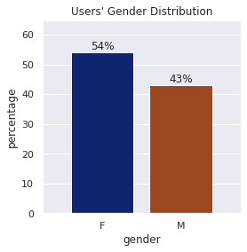

```python
# barplot for gender distribution

# set size and font
sns.set(rc = {"figure.figsize":(4,4)})
sns.set(font_scale=1)

# create the plot
ax = sns.barplot(x='gender', y="percentage",
                 data=df_gender.toPandas(), palette="dark")

# create labels
ax.bar_label(ax.containers[0], fmt='%.f%%');

# pad margins so that markers don't get clipped by the axes
plt.margins(0.2)

# create title
plt.title("Users' Gender Distribution");
```

### location Column

```python
# take a look at sample location records
df.select(["location"]).show(6, truncate=False)
```

```
+------------------------------+
|location                      |
+------------------------------+
|Bakersfield, CA               |
|Boston-Cambridge-Newton, MA-NH|
|Bakersfield, CA               |
|Boston-Cambridge-Newton, MA-NH|
|Bakersfield, CA               |
|Boston-Cambridge-Newton, MA-NH|
+------------------------------+
only showing top 6 rows
```

```python
# split the location column in two columns: city and state
df = df.withColumn("city", split(df["location"], ",").getItem(0)) \
        .withColumn("state", split(df["location"], ",").getItem(1))

df.show(1, truncate=True, vertical=True)
```

```
-RECORD 0-----------------------------
 artist        | Martha Tilston
 auth          | Logged In
 firstName     | Colin
 gender        | M
 itemInSession | 50
 lastName      | Freeman
 length        | 277.89016
 level         | paid
 location      | Bakersfield, CA
 method        | PUT
 page          | NextSong
 registration  | 1538173362000
 sessionId     | 29
 song          | Rockpools
 status        | 200
 ts            | 1538352117000
 userAgent     | Mozilla/5.0 (Wind...
 userId        | 30
 city          | Bakersfield
 state         |  CA
only showing top 1 row
```

```python
# drop the initial location column and check the outcome
df.drop(df.location).printSchema()
```

```
root
 |-- artist: string (nullable = true)
 |-- auth: string (nullable = true)
 |-- firstName: string (nullable = true)
 |-- gender: string (nullable = true)
 |-- itemInSession: long (nullable = true)
 |-- lastName: string (nullable = true)
 |-- length: double (nullable = true)
 |-- level: string (nullable = true)
 |-- method: string (nullable = true)
 |-- page: string (nullable = true)
 |-- registration: long (nullable = true)
 |-- sessionId: long (nullable = true)
 |-- song: string (nullable = true)
 |-- status: long (nullable = true)
 |-- ts: long (nullable = true)
 |-- userAgent: string (nullable = true)
 |-- userId: string (nullable = true)
 |-- city: string (nullable = true)
 |-- state: string (nullable = true)
```

```python
# take a look at the distribution of sessions by state
df.groupBy("state").count().show(10)
```

```
+------------+-----+
|       state|count|
+------------+-----+
|       NE-IA|  187|
|       PA-NJ|  815|
|          WA| 3772|
| DC-VA-MD-WV| 3090|
|          AL| 2857|
|          MI| 7216|
|       MN-WI| 2241|
|    IL-IN-WI| 5114|
|        null| 8346|
|       MD-WV|  982|
+------------+-----+
only showing top 10 rows
```

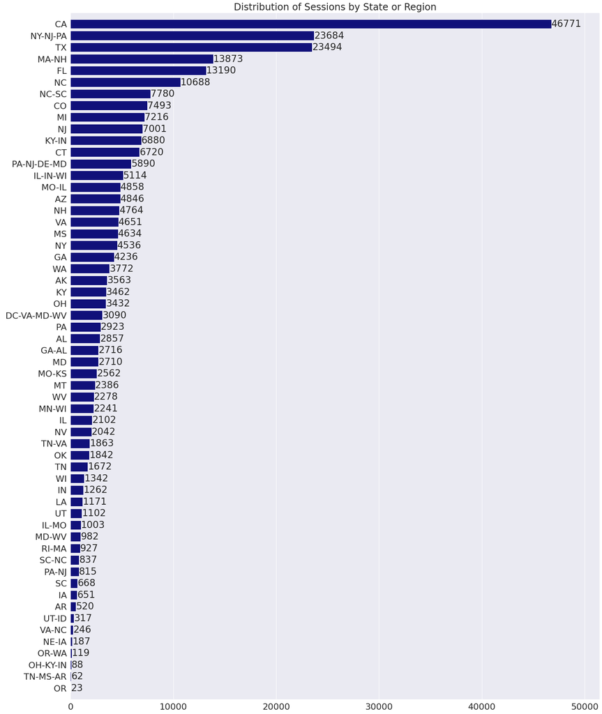

```python
# visualize the distribution of sessions by state

# adjust figure size and font size
sns.set(rc = {"figure.figsize":(24,32)})
sns.set(font_scale=2)

# plot the distribution by state
ax = sns.countplot(y="state", data=df.toPandas(),
                  order = df.toPandas()["state"] \
                   .value_counts().index,
                  color="darkblue")

# pad margins so that markers don't get clipped by the axes
plt.margins(x=0.1, y=0.01, tight=True)

# create labels and title
ax.bar_label(ax.containers[0]);
ax.set(ylabel=None)
ax.set(xlabel=None)
plt.title("Distribution of Sessions by State or Region");
```

```python
# count the users by state

user_by_state = df.groupBy(["state"]).agg(countDistinct("userId"))
user_by_state.show(4)
```

```
+------------+-------------+
|       state|count(userId)|
+------------+-------------+
|       NE-IA|            1|
|       PA-NJ|            1|
|          WA|            4|
| DC-VA-MD-WV|            4|
+------------+-------------+
only showing top 4 rows
```

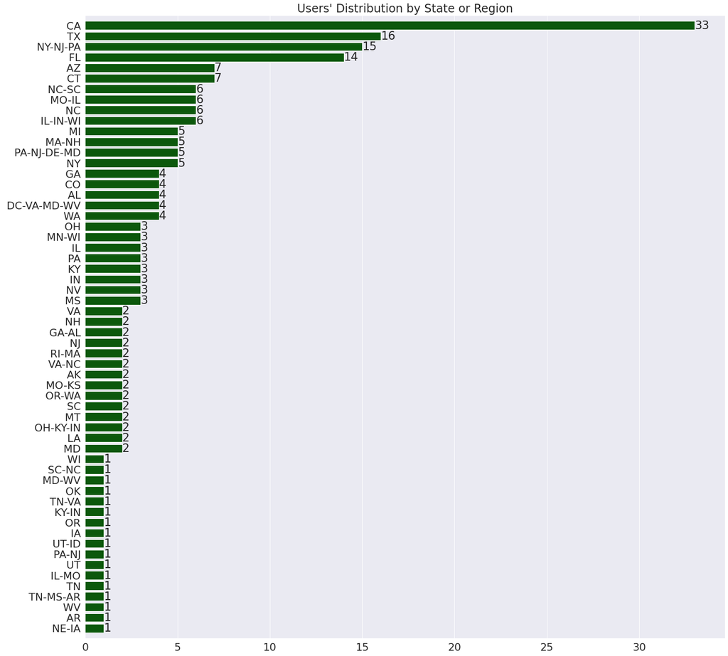

```python
# adjust figure size and font size
sns.set(rc = {"figure.figsize":(24,24)})
sns.set(font_scale=2)

data = user_by_state.toPandas().sort_values(by="count(userId)",ascending=False)

# plot the distribution of users by state
ax = sns.barplot(y="state", x = "count(userId)", data=data,
                  color="darkgreen")

# pad margins so that markers don't get clipped by the axes
plt.margins(x=0.05, y=0.01, tight=True)

# create labels and title
ax.bar_label(ax.containers[0]);
ax.set(ylabel=None)
ax.set(xlabel=None)
plt.title("Users' Distribution by State or Region");
```

The users' records are from 58 states and regions (groups of 2-3 states). The distribution of the users among these states is very uneven, with CA having the largest number of users (33), most of the other states have less than 10 users.

### userAgent Column

```python
# peek at the userAgent entries available in the dataset
df.groupBy("userAgent").count().show(4, truncate=False)
```

```
+--------------------------------------------------------------------------------------------------------------------------+-----+
|userAgent                                                                                                                 |count|
+--------------------------------------------------------------------------------------------------------------------------+-----+
|"Mozilla/5.0 (Macintosh; Intel Mac OS X 10_8_5) AppleWebKit/537.36 (KHTML, like Gecko) Chrome/36.0.1985.143 Safari/537.36"|240  |
|"Mozilla/5.0 (Windows NT 5.1) AppleWebKit/537.36 (KHTML, like Gecko) Chrome/36.0.1985.143 Safari/537.36"                  |5238 |
|Mozilla/5.0 (X11; Ubuntu; Linux i686; rv:31.0) Gecko/20100101 Firefox/31.0                                                |62   |
|"Mozilla/5.0 (Macintosh; Intel Mac OS X 10_9_4) AppleWebKit/537.36 (KHTML, like Gecko) Chrome/36.0.1985.125 Safari/537.36"|18448|
+--------------------------------------------------------------------------------------------------------------------------+-----+
only showing top 4 rows
```

```python
# userAgent groupped by userId
df_userAgent = df \
    .groupBy(["userAgent"]) \
    .agg(countDistinct("userId")) \
    .sort(["count(userId)"], ascending=False)
df_userAgent.show(10,truncate=True)
```

```
+--------------------+-------------+
|           userAgent|count(userId)|
+--------------------+-------------+
|"Mozilla/5.0 (Win...|           24|
|Mozilla/5.0 (Wind...|           18|
|"Mozilla/5.0 (Mac...|           16|
|"Mozilla/5.0 (Mac...|           12|
|"Mozilla/5.0 (Mac...|           12|
|"Mozilla/5.0 (Mac...|           10|
|"Mozilla/5.0 (Win...|           10|
|Mozilla/5.0 (Maci...|            9|
|"Mozilla/5.0 (iPh...|            8|
|Mozilla/5.0 (Wind...|            7|
+--------------------+-------------+
only showing top 10 rows
```

The User-Agent request header is a characteristic string that lets servers and network peers identify the application, operating system, vendor, and/or version of the requesting user agent.

The common format for web browsers is: Mozilla/5.0 () ()

Syntax and common format for the most popular web browsers can be found [**here**](https://developer.mozilla.org/en-US/docs/Web/HTTP/Headers/User-Agent).

There are 56 user-agents available in the dataset, the specifics of each entry can be identified using this [**webapp**](http://www.browser-info.net/useragentl).

For example: *Mozilla/5.0 (compatible; MSIE 9.0; Windows NT 6.1; Trident/5.0)* corresponds to Microsoft Internet Explorer 9.0 on a Windows 7.

### level Column

```python
# level counts and percentages, to distinguish between paid and free tier

df_level = df \
            .filter(col("level").isNotNull()) \
            .groupby("level") \
            .agg((count("level")) \
            .alias("count"),
                 (Fround(count("level") / df.count(), 2)*100) \
                 .alias("percentage"))

df_level.show()
```

```
+-----+------+----------+
|level| count|percentage|
+-----+------+----------+
| free| 58338|      20.0|
| paid|228162|      80.0|
+-----+------+----------+
```

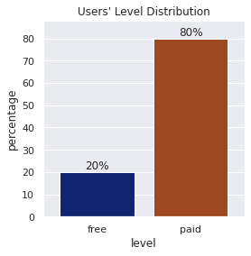

```python
# barplot for level distribution

# set figure size and font scale
sns.set(rc = {"figure.figsize":(4,4)})
sns.set(font_scale=1)

# create the plot
ax = sns.barplot(x="level", y="percentage",
                 data=df_level.toPandas(), palette="dark")

# pad margins so that markers don't get clipped by the axes
plt.margins(x=0.1, y=0.1, tight=True);

# create labels and title
ax.bar_label(ax.containers[0], fmt='%.f%%');
plt.title("Users' Level Distribution");
```

### registration, ts Columns

```python
# convert the timestamp in registration and ts into datetime format
df = df.withColumn("event_ts", from_unixtime(col("ts")/1000.0))
df = df.withColumn("date_reg", from_unixtime(col("registration")/1000.0))
# check the output
df.select("userId", "sessionId", "registration", "ts", "event_ts", "date_reg").show(4)
```

```
+------+---------+-------------+-------------+-------------------+-------------------+
|userId|sessionId| registration|           ts|           event_ts|           date_reg|
+------+---------+-------------+-------------+-------------------+-------------------+
|    30|       29|1538173362000|1538352117000|2018-09-30 20:01:57|2018-09-28 18:22:42|
|     9|        8|1538331630000|1538352180000|2018-09-30 20:03:00|2018-09-30 14:20:30|
|    30|       29|1538173362000|1538352394000|2018-09-30 20:06:34|2018-09-28 18:22:42|
|     9|        8|1538331630000|1538352416000|2018-09-30 20:06:56|2018-09-30 14:20:30|
+------+---------+-------------+-------------+-------------------+-------------------+
only showing top 4 rows
```

```python
# extract day of the month in a separate column
df = df.withColumn("day_ts", dayofmonth(df.event_ts))
df = df.withColumn("day_reg", dayofmonth(df.date_reg))
# check the output
df.select("userId", "sessionId", "event_ts", "date_reg", "day_ts", "day_reg").show(4)
```

```
+------+---------+-------------------+-------------------+------+-------+
|userId|sessionId|           event_ts|           date_reg|day_ts|day_reg|
+------+---------+-------------------+-------------------+------+-------+
|    30|       29|2018-09-30 20:01:57|2018-09-28 18:22:42|    30|     28|
|     9|        8|2018-09-30 20:03:00|2018-09-30 14:20:30|    30|     30|
|    30|       29|2018-09-30 20:06:34|2018-09-28 18:22:42|    30|     28|
|     9|        8|2018-09-30 20:06:56|2018-09-30 14:20:30|    30|     30|
+------+---------+-------------------+-------------------+------+-------+
only showing top 4 rows
```

```python
# extract day of the week in words
df=df.withColumn("weekday_ts", date_format(col("event_ts"), "EEEE"))
df=df.withColumn("weekday_reg", date_format(col("date_reg"), "EEEE"))
# check the output
df.select("userId", "sessionId", "event_ts", "date_reg", "weekday_ts", "weekday_reg").show(4)
```

```
+------+---------+-------------------+-------------------+----------+-----------+
|userId|sessionId|           event_ts|           date_reg|weekday_ts|weekday_reg|
+------+---------+-------------------+-------------------+----------+-----------+
|    30|       29|2018-09-30 20:01:57|2018-09-28 18:22:42|    Sunday|     Friday|
|     9|        8|2018-09-30 20:03:00|2018-09-30 14:20:30|    Sunday|     Sunday|
|    30|       29|2018-09-30 20:06:34|2018-09-28 18:22:42|    Sunday|     Friday|
|     9|        8|2018-09-30 20:06:56|2018-09-30 14:20:30|    Sunday|     Sunday|
+------+---------+-------------------+-------------------+----------+-----------+
only showing top 4 rows
```

```python
# extract month from date
df = df.withColumn("month_ts",month(df.event_ts))
df = df.withColumn("month_reg",month(df.date_reg))
# check the output
df.select("userId", "sessionId", "event_ts", "date_reg", "month_ts", "month_reg").show(4)
```

```
+------+---------+-------------------+-------------------+--------+---------+
|userId|sessionId|           event_ts|           date_reg|month_ts|month_reg|
+------+---------+-------------------+-------------------+--------+---------+
|    30|       29|2018-09-30 20:01:57|2018-09-28 18:22:42|       9|        9|
|     9|        8|2018-09-30 20:03:00|2018-09-30 14:20:30|       9|        9|
|    30|       29|2018-09-30 20:06:34|2018-09-28 18:22:42|       9|        9|
|     9|        8|2018-09-30 20:06:56|2018-09-30 14:20:30|       9|        9|
+------+---------+-------------------+-------------------+--------+---------+
only showing top 4 rows
```

```python
# get session hour from timestamp
df = df.withColumn("hour_ts",hour(df.event_ts))
# check the output
df.select("userId", "sessionId", "event_ts", "date_reg", "hour_ts").show(4)
```

```
+------+---------+-------------------+-------------------+-------+
|userId|sessionId|           event_ts|           date_reg|hour_ts|
+------+---------+-------------------+-------------------+-------+
|    30|       29|2018-09-30 20:01:57|2018-09-28 18:22:42|     20|
|     9|        8|2018-09-30 20:03:00|2018-09-30 14:20:30|     20|
|    30|       29|2018-09-30 20:06:34|2018-09-28 18:22:42|     20|
|     9|        8|2018-09-30 20:06:56|2018-09-30 14:20:30|     20|
+------+---------+-------------------+-------------------+-------+
only showing top 4 rows
```

```python
# take a look at the statistics for the two columns registration and ts
reg_ts = df.describe("registration", "ts")
reg_ts.show()
```

```
+-------+--------------------+--------------------+
|summary|        registration|                  ts|
+-------+--------------------+--------------------+
|  count|              278154|              286500|
|   mean|1.535358834085557...|1.540956889810471...|
| stddev|3.2913216163276587E9| 1.507543960823119E9|
|    min|       1521380675000|       1538352117000|
|    max|       1543247354000|       1543799476000|
+-------+--------------------+--------------------+
```

```python
# the earliest and the latest sessions in the dataset
mindate = df.agg(Fmin("event_ts")).toPandas()
maxdate = df.agg(Fmax("event_ts")).toPandas()

# print the start date and the end date of the period in the dataset
print("The first session recorded is on {}.".format(mindate["min(event_ts)"][0]))
print("The last session recorded is on {}.".format(maxdate["max(event_ts)"][0]))
```

```
The first session recorded is on 2018-09-30 20:01:57.
The last session recorded is on 2018-12-02 20:11:16.
```

```python
# the earliest and the latest user registration in the dataset
mindatereg = df.agg(Fmin("date_reg")).toPandas()
maxdatereg = df.agg(Fmax("date_reg")).toPandas()

# print the start date and the end date of the period for user registration
print("The first session recorded is on {}.".format(mindatereg["min(date_reg)"][0]))
print("The last session recorded is on {}.".format(maxdatereg["max(date_reg)"][0]))
```

```
The first session recorded is on 2018-03-18 09:44:35.
The last session recorded is on 2018-11-26 10:49:14.
```

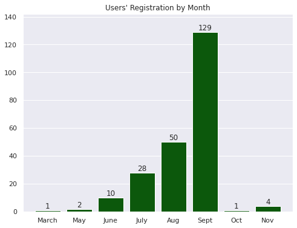

```python
# visualize user registration by month

# count the users by the month they registered
reg_by_month = df.groupBy(["month_reg"]).agg(countDistinct("userId"))

# adjust figure size and font size
sns.set(rc = {"figure.figsize":(8,6)})
sns.set(font_scale=1)

# create plot
data = reg_by_month.toPandas().sort_values(by="count(userId)",ascending=False)
months = ["March", "May", "June", "July", "Aug", "Sept", "Oct", "Nov"]

# plot the distribution of users by state
ax = sns.barplot(x="month_reg", y="count(userId)", data=data,
                  color="darkgreen")

# pad margins so that markers don't get clipped by the axes
plt.margins(x=0.05, y=0.1, tight=True);

# create labels and title
ax.bar_label(ax.containers[0]);
ax.set(ylabel=None)
ax.set(xlabel=None)
ax.set_xticklabels(months)
plt.title("Users' Registration by Month");
```

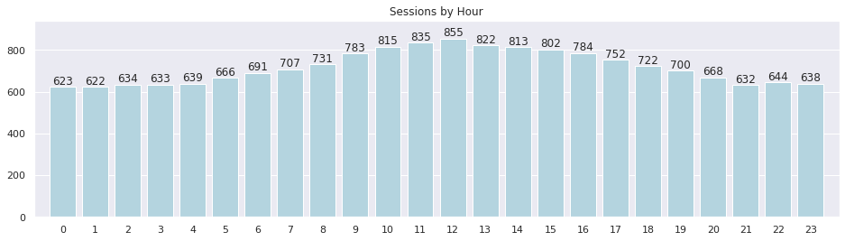

```python
# visualize sessions by hour

# count sessions by hour
session_by_hour = df.groupBy(["hour_ts"]).agg(countDistinct("sessionId"))

# adjust figure size and font size
sns.set(rc = {"figure.figsize":(16,4)})
sns.set(font_scale=1)

data = session_by_hour.toPandas().sort_values(by="count(sessionId)",ascending=False)

# plot the distribution of users by hour
ax = sns.barplot(x="hour_ts", y="count(sessionId)", data=data,
                  color="lightblue")

# pad margins so that markers don't get clipped by the axes
plt.margins(x=0.02, y=0.1, tight=True);

# create labels and title
ax.bar_label(ax.containers[0]);
ax.set(ylabel=None)
ax.set(xlabel=None)
plt.title("Sessions by Hour");
```

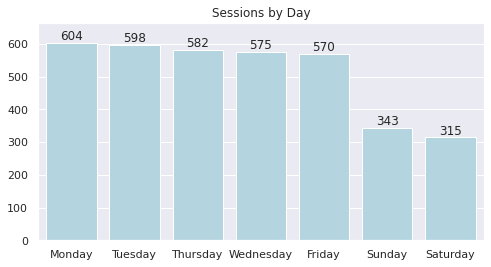

```python
# visualize sessions by day of the week

# count sessions by day of the week
session_by_weekday = df.groupBy(["weekday_ts"]).agg(countDistinct("sessionId"))

# adjust figure size and font size
sns.set(rc = {"figure.figsize":(8,4)})
sns.set(font_scale=1)

data = session_by_weekday.toPandas().sort_values(by="count(sessionId)",ascending=False)

# plot the distribution of users by day of the week
ax = sns.barplot(x="weekday_ts", y="count(sessionId)", data=data,
                  color="lightblue")

# pad margins so that markers don't get clipped by the axes
plt.margins(x=0.02, y=0.1, tight=True);

# create labels and title
ax.bar_label(ax.containers[0]);
ax.set(ylabel=None)
ax.set(xlabel=None)
plt.title("Sessions by Day");
```

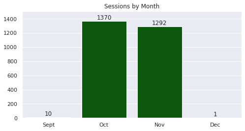

```python
# visualize sessions by month

# count sessions by month
session_by_month = df.groupBy(["month_ts"]).agg(countDistinct("sessionId"))

# adjust figure size and font size
sns.set(rc = {"figure.figsize":(8,4)})
sns.set(font_scale=1)

data = session_by_month.toPandas().sort_values(by="count(sessionId)",ascending=False)
month = ["Sept", "Oct", "Nov", "Dec"]

# plot the distribution of users by state
ax = sns.barplot(x="month_ts", y="count(sessionId)", data=data,
                  color="darkgreen")

# pad margins so that markers don't get clipped by the axes
plt.margins(x=0.02, y=0.1, tight=True);

# create labels and title
ax.bar_label(ax.containers[0]);
ax.set(ylabel=None)
ax.set(xlabel=None)
ax.set_xticklabels(month)
plt.title("Sessions by Month");
```

[Unix time](https://en.wikipedia.org/wiki/Unix_time) is also known as Epoch time which specifies the moment in time since 1970-01-01 00:00:00 UTC. It is the number of seconds passed since Epoch time. Epoch time is widely used in Unix like operating systems. Both columns correspond to timestamps given miliseconds in Unix time, the _registration_ for the date and time when the user registered with the platform while _ts_ corresponds to the session timestamp. After converting the data in _registration_ and _ts_, we learn that the dataset is based on users that registered in 2018 between March and November, with a sharp increase in registrations in September. The sessions are also from 2018, mostly from October and November. We also learn that the most popular listening times are around noon, and that the users listen more during the week days than on the wekend.

### method Column

The Hypertext Transfer Protocol (HTTP) is designed to enable communications between clients and servers. HTTP works as a request-response protocol between a client and server. _GET_ is used to request data from a specified resource. _PUT_ is used to send data to a server to create/update a resource; see [HTTP Request Forms](https://www.w3schools.com/tags/ref_httpmethods.asp).

```python
# the HTTP request method initiated by user, counts and percentages
df_method = df.groupBy("method").count()
df_method.show()
```

```
+------+------+
|method| count|
+------+------+
|   PUT|261064|
|   GET| 25436|
+------+------+
```

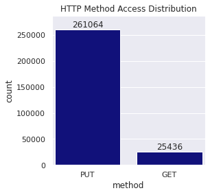

```python
# visualize the distribution of sessions by method

# adjust figure size and font size
sns.set(rc = {"figure.figsize":(4,4)})
sns.set(font_scale=1)

# plot the distribution of users by state
ax = sns.barplot(x="method", y="count", data=df_method.toPandas(),
                  color="darkblue")

# pad margins so that markers don't get clipped by the axes
plt.margins(x=0.02, y=0.1, tight=True);

# create labels and title
ax.bar_label(ax.containers[0]);
plt.title("HTTP Method Access Distribution");
```

### status Column

The entries represent HTTP status codes. Three such codes can be found in this dataset: - 200 - OK, the request has succeeded - 307 - temporary redirect - 404 - not found For a full list see: [HTTP Status Codes Definitions](https://www.w3.org/Protocols/rfc2616/rfc2616-sec10.html).

```python
# the HTTP status codes distribution
df_status = df.groupBy("status").count()
df_status.show()
```

```
+------+------+
|status| count|
+------+------+
|   307| 26430|
|   404|   258|
|   200|259812|
+------+------+
```

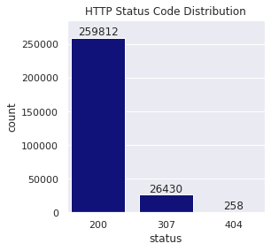

```python
# visualize the distribution of sessions by method

# adjust figure size and font size
sns.set(rc = {"figure.figsize":(4,4)})
sns.set(font_scale=1)

# plot the distribution of HTTP status by session
ax = sns.barplot(x="status", y="count", data=df_status.toPandas(),
                  color="darkblue")

# pad margins so that markers don't get clipped by the axes
plt.margins(x=0.02, y=0.1, tight=True);

# create labels and title
ax.bar_label(ax.containers[0]);
plt.title("HTTP Status Code Distribution");
```

```python
# take a look at the entries that have status 404
df_error = df.filter(df["status"] == 404)
df_error.show(4)
```

```
+------+---------+---------+------+-------------+--------+------+-----+--------------------+------+-----+-------------+---------+----+------+-------------+--------------------+------+--------------------+------+-------------------+-------------------+------+-------+----------+-----------+--------+--…
|artist|     auth|firstName|gender|itemInSession|lastName|length|level|            location|method| page| registration|sessionId|song|status|           ts|           userAgent|userId|                city| state|           event_ts|           date_reg|day_ts|day_reg|weekday_ts|weekday_reg|month_ts|mo…
+------+---------+---------+------+-------------+--------+------+-----+--------------------+------+-----+-------------+---------+----+------+-------------+--------------------+------+--------------------+------+-------------------+-------------------+------+-------+----------+-----------+--------+--…
|  null|Logged In|     Kael|     M|           48|   Baker|  null| paid|Kingsport-Bristol...|   GET|Error|1533102330000|      249|null|   404|1538393848000|"Mozilla/5.0 (Mac...|   131|Kingsport-Bristol...| TN-VA|2018-10-01 07:37:28|2018-08-01 01:45:30|     1|      1|    Monday|  Wednesday|      10|  …
|  null|Logged In|   Lucero|     F|           10|    Reed|  null| free|Louisville/Jeffer...|   GET|Error|1536642109000|      139|null|   404|1538407927000|"Mozilla/5.0 (Win...|   140|Louisville/Jeffer...| KY-IN|2018-10-01 11:32:07|2018-09-11 01:01:49|     1|     11|    Monday|    Tuesday|      10|  …
|  null|Logged In|Sebastian|     M|           38|    Wang|  null| free|         Jackson, MS|   GET|Error|1538050164000|       52|null|   404|1538425401000|"Mozilla/5.0 (Mac...|    53|             Jackson|    MS|2018-10-01 16:23:21|2018-09-27 08:09:24|     1|     27|    Monday|   Thursday|      10|  …
|  null|Logged In|    Micah|     M|           38|    Long|  null| free|Boston-Cambridge-...|   GET|Error|1538331630000|      262|null|   404|1538489751000|"Mozilla/5.0 (Win...|     9|Boston-Cambridge-...| MA-NH|2018-10-02 10:15:51|2018-09-30 14:20:30|     2|     30|   Tuesday|     Sunday|      10|  …
+------+---------+---------+------+-------------+--------+------+-----+--------------------+------+-----+-------------+---------+----+------+-------------+--------------------+------+--------------------+------+-------------------+-------------------+------+-------+----------+-----------+--------+--…
only showing top 4 rows
```

```
21/12/21 09:49:30 WARN package: Truncated the string representation of a plan since it was too large. This behavior can be adjusted by setting 'spark.sql.debug.maxToStringFields'.
```

```python
# a look at the other columns when status = 404, count distinct entries in each
df_error.select([countDistinct(c) .alias(c) for c in df.columns]).show(vertical=True)
```

```
-RECORD 0------------
 artist        | 0
 auth          | 3
 firstName     | 109
 gender        | 2
 itemInSession | 157
 lastName      | 92
 length        | 0
 level         | 2
 location      | 75
 method        | 1
 page          | 1
 registration  | 117
 sessionId     | 230
 song          | 0
 status        | 1
 ts            | 258
 userAgent     | 44
 userId        | 118
 city          | 74
 state         | 45
 event_ts      | 258
 date_reg      | 117
 day_ts        | 31
 day_reg       | 29
 weekday_ts    | 7
 weekday_reg   | 7
 month_ts      | 2
 month_reg     | 8
 hour_ts       | 24
```

```python
# determine how many records have status 404
print("There are {} records where the HTTP status is 404, page not found." \
      .format(df_error.count()))
```

```
There are 258 records where the HTTP status is 404, page not found.
```

```python
# take a look at the paid customers that have status 404
df_error_paid = df_error.filter(df["level"] == "paid")
df_error_paid.show(4)
```

```
+------+---------+---------+------+-------------+--------+------+-----+--------------------+------+-----+-------------+---------+----+------+-------------+--------------------+------+--------------------+------+-------------------+-------------------+------+-------+----------+-----------+--------+--…
|artist|     auth|firstName|gender|itemInSession|lastName|length|level|            location|method| page| registration|sessionId|song|status|           ts|           userAgent|userId|                city| state|           event_ts|           date_reg|day_ts|day_reg|weekday_ts|weekday_reg|month_ts|mo…
+------+---------+---------+------+-------------+--------+------+-----+--------------------+------+-----+-------------+---------+----+------+-------------+--------------------+------+--------------------+------+-------------------+-------------------+------+-------+----------+-----------+--------+--…
|  null|Logged In|     Kael|     M|           48|   Baker|  null| paid|Kingsport-Bristol...|   GET|Error|1533102330000|      249|null|   404|1538393848000|"Mozilla/5.0 (Mac...|   131|Kingsport-Bristol...| TN-VA|2018-10-01 07:37:28|2018-08-01 01:45:30|     1|      1|    Monday|  Wednesday|      10|  …
|  null|Logged In|Alexander|     M|          189|  Garcia|  null| paid|Indianapolis-Carm...|   GET|Error|1536817381000|      104|null|   404|1538547956000|Mozilla/5.0 (Wind...|   105|Indianapolis-Carm...|    IN|2018-10-03 02:25:56|2018-09-13 01:43:01|     3|     13| Wednesday|   Thursday|      10|  …
|  null|Logged In|    Panav|     M|           76|   Myers|  null| paid|      Morgantown, WV|   GET|Error|1538239045000|      287|null|   404|1538572413000|"Mozilla/5.0 (Win...|    15|          Morgantown|    WV|2018-10-03 09:13:33|2018-09-29 12:37:25|     3|     29| Wednesday|   Saturday|      10|  …
|  null|Logged In|   Nicole|     F|          100|    Beck|  null| paid|Vineland-Bridgeto...|   GET|Error|1532224335000|      420|null|   404|1538673969000|"Mozilla/5.0 (Mac...|   124|  Vineland-Bridgeton|    NJ|2018-10-04 13:26:09|2018-07-21 21:52:15|     4|     21|  Thursday|   Saturday|      10|  …
+------+---------+---------+------+-------------+--------+------+-----+--------------------+------+-----+-------------+---------+----+------+-------------+--------------------+------+--------------------+------+-------------------+-------------------+------+-------+----------+-----------+--------+--…
only showing top 4 rows
```

```python
# take a closer look at the sessions of a paid customer
df_error_paid.filter(df_error_paid["userId"]=="124").show()
```

```
+------+---------+---------+------+-------------+--------+------+-----+--------------------+------+-----+-------------+---------+----+------+-------------+--------------------+------+------------------+-----+-------------------+-------------------+------+-------+----------+-----------+--------+-----…
|artist|     auth|firstName|gender|itemInSession|lastName|length|level|            location|method| page| registration|sessionId|song|status|           ts|           userAgent|userId|              city|state|           event_ts|           date_reg|day_ts|day_reg|weekday_ts|weekday_reg|month_ts|month…
+------+---------+---------+------+-------------+--------+------+-----+--------------------+------+-----+-------------+---------+----+------+-------------+--------------------+------+------------------+-----+-------------------+-------------------+------+-------+----------+-----------+--------+-----…
|  null|Logged In|   Nicole|     F|          100|    Beck|  null| paid|Vineland-Bridgeto...|   GET|Error|1532224335000|      420|null|   404|1538673969000|"Mozilla/5.0 (Mac...|   124|Vineland-Bridgeton|   NJ|2018-10-04 13:26:09|2018-07-21 21:52:15|     4|     21|  Thursday|   Saturday|      10|     …
|  null|Logged In|   Nicole|     F|          346|    Beck|  null| paid|Vineland-Bridgeto...|   GET|Error|1532224335000|      420|null|   404|1538724012000|"Mozilla/5.0 (Mac...|   124|Vineland-Bridgeton|   NJ|2018-10-05 03:20:12|2018-07-21 21:52:15|     5|     21|    Friday|   Saturday|      10|     …
|  null|Logged In|   Nicole|     F|           62|    Beck|  null| paid|Vineland-Bridgeto...|   GET|Error|1532224335000|      517|null|   404|1539027101000|"Mozilla/5.0 (Mac...|   124|Vineland-Bridgeton|   NJ|2018-10-08 15:31:41|2018-07-21 21:52:15|     8|     21|    Monday|   Saturday|      10|     …
|  null|Logged In|   Nicole|     F|          305|    Beck|  null| paid|Vineland-Bridgeto...|   GET|Error|1532224335000|      708|null|   404|1539740355000|"Mozilla/5.0 (Mac...|   124|Vineland-Bridgeton|   NJ|2018-10-16 21:39:15|2018-07-21 21:52:15|    16|     21|   Tuesday|   Saturday|      10|     …
|  null|Logged In|   Nicole|     F|          341|    Beck|  null| paid|Vineland-Bridgeto...|   GET|Error|1532224335000|      708|null|   404|1539746713000|"Mozilla/5.0 (Mac...|   124|Vineland-Bridgeton|   NJ|2018-10-16 23:25:13|2018-07-21 21:52:15|    16|     21|   Tuesday|   Saturday|      10|     …
|  null|Logged In|   Nicole|     F|           99|    Beck|  null| paid|Vineland-Bridgeto...|   GET|Error|1532224335000|     2372|null|   404|1543515887000|"Mozilla/5.0 (Mac...|   124|Vineland-Bridgeton|   NJ|2018-11-29 13:24:47|2018-07-21 21:52:15|    29|     21|  Thursday|   Saturday|      11|     …
+------+---------+---------+------+-------------+--------+------+-----+--------------------+------+-----+-------------+---------+----+------+-------------+--------------------+------+------------------+-----+-------------------+-------------------+------+-------+----------+-----------+--------+-----…
```

There are 258 rows in the data that have status 404, page no found. - All these records have _GET_ as HTTP method. - Some paid customers, such as the _userId_=124 have multiple sessions where _status_ = 404. Although there are only a handful of such errors in the sample dataset, we have to investigate them in the full dataset also. Having troubles in logging in is a possible reason for a paid customer to cancel the subscription.

### auth Column

```python
# the entries in auth column indicate the activity type of the user
df_auth = df.groupBy("auth").count()
df_auth.show()
```

```
+----------+------+
|      auth| count|
+----------+------+
|Logged Out|  8249|
| Cancelled|    52|
|     Guest|    97|
| Logged In|278102|
+----------+------+
```

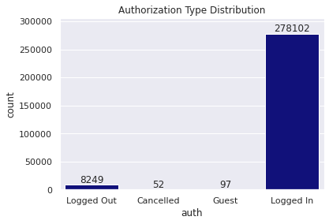

```python
# visualize the distribution of the authorization type

# adjust figure size and font size
sns.set(rc = {"figure.figsize":(6,4)})
sns.set(font_scale=1)

# plot the distribution of HTTP status by session
ax = sns.barplot(x="auth", y="count", data=df_auth.toPandas(),
                  color="darkblue")

# pad margins so that markers don't get clipped by the axes
plt.margins(x=0.02, y=0.1, tight=True);

# create labels and title
ax.bar_label(ax.containers[0]);
plt.title("Authorization Type Distribution");
```

```python
# take a look at the users that cancelled
df_cancelled = df.filter(df["auth"] == "Cancelled")
df_cancelled.show(4)
```

```
+------+---------+---------+------+-------------+--------+------+-----+--------------------+------+--------------------+-------------+---------+----+------+-------------+--------------------+------+--------------------+------+-------------------+-------------------+------+-------+----------+--------…
|artist|     auth|firstName|gender|itemInSession|lastName|length|level|            location|method|                page| registration|sessionId|song|status|           ts|           userAgent|userId|                city| state|           event_ts|           date_reg|day_ts|day_reg|weekday_ts|weekday_…
+------+---------+---------+------+-------------+--------+------+-----+--------------------+------+--------------------+-------------+---------+----+------+-------------+--------------------+------+--------------------+------+-------------------+-------------------+------+-------+----------+--------…
|  null|Cancelled|   Adriel|     M|          104| Mendoza|  null| paid|  Kansas City, MO-KS|   GET|Cancellation Conf...|1535623466000|      514|null|   200|1538943990000|"Mozilla/5.0 (Mac...|    18|         Kansas City| MO-KS|2018-10-07 16:26:30|2018-08-30 06:04:26|     7|     30|    Sunday|   Thurs…
|  null|Cancelled|    Diego|     M|           56|   Mckee|  null| paid|Phoenix-Mesa-Scot...|   GET|Cancellation Conf...|1537167593000|      540|null|   200|1539033046000|"Mozilla/5.0 (iPh...|    32|Phoenix-Mesa-Scot...|    AZ|2018-10-08 17:10:46|2018-09-17 02:59:53|     8|     17|    Monday|     Mon…
|  null|Cancelled|    Mason|     M|           10|    Hart|  null| free|  Corpus Christi, TX|   GET|Cancellation Conf...|1533157139000|      174|null|   200|1539318918000|"Mozilla/5.0 (Mac...|   125|      Corpus Christi|    TX|2018-10-12 00:35:18|2018-08-01 16:58:59|    12|      1|    Friday|  Wednes…
|  null|Cancelled|Alexander|     M|          332|  Garcia|  null| paid|Indianapolis-Carm...|   GET|Cancellation Conf...|1536817381000|      508|null|   200|1539375441000|Mozilla/5.0 (Wind...|   105|Indianapolis-Carm...|    IN|2018-10-12 16:17:21|2018-09-13 01:43:01|    12|     13|    Friday|   Thurs…
+------+---------+---------+------+-------------+--------+------+-----+--------------------+------+--------------------+-------------+---------+----+------+-------------+--------------------+------+--------------------+------+-------------------+-------------------+------+-------+----------+--------…
only showing top 4 rows
```

### page Column

```python
# create a dataframe with unique distinct types of actions - pages
pages_collect = df.select("page") \
        .where(col("page").isNotNull()) \
        .distinct() \
        .collect()

# collect all the pages in a list
pages = []
print('\nThe following pages are available for the users:\n')
for row in pages_collect:
    # create a list of pages
    pages.append(str(row['page']))
    # print the page name
    print(str(row['page']))
```

```
The following pages are available for the users:

Cancel
Submit Downgrade
Thumbs Down
Home
Downgrade
Roll Advert
Logout
Save Settings
Cancellation Confirmation
About
Submit Registration
Settings
Login
Register
Add to Playlist
Add Friend
NextSong
Thumbs Up
Help
Upgrade
Error
Submit Upgrade
```

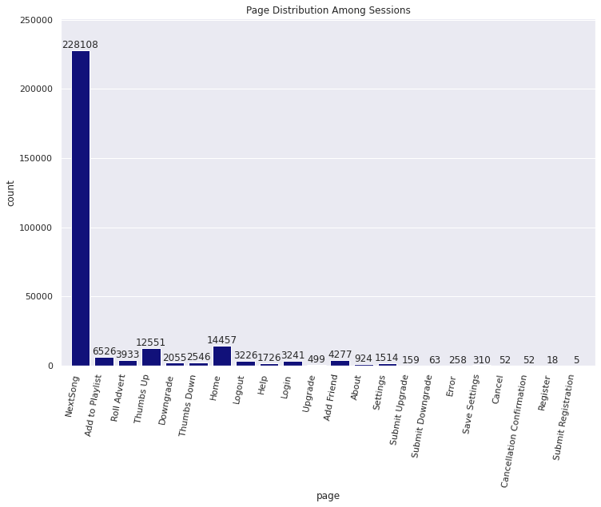

```python
# adjust figure size and font size
sns.set(rc = {"figure.figsize":(12,8)})
sns.set(font_scale=1)

# plot the page distribution
ax = sns.countplot(x="page", data=df.toPandas(),
                  color="darkblue")

# pad margins so that markers don't get clipped by the axes
plt.margins(x=0.02, y=0.1, tight=True);

# create labels and title
ax.bar_label(ax.containers[0]);

plt.xticks(rotation=80, horizontalalignment="right");
plt.title("Page Distribution Among Sessions");
```

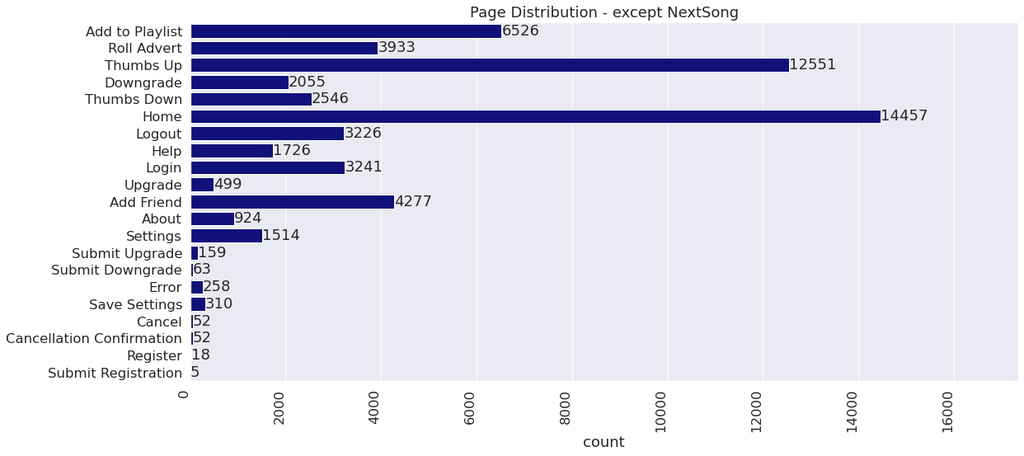

```python
# plot the pages other than NextSong
df_pages = df.filter(df["page"] != "NextSong")

# adjust figure size and font size
sns.set(rc = {'figure.figsize':(18,8)})
sns.set(font_scale=1.5)

# pad margins so that markers don't get clipped by the axes
plt.margins(x=0.2, y=0.4, tight=True);

# plot the page distribution
ax = sns.countplot(y="page", data=df_pages.toPandas(), color="darkblue")
ax.bar_label(ax.containers[0]);
ax.set(ylabel=None)
plt.xticks(rotation=90, horizontalalignment='right');
ax.set_title("Page Distribution - except NextSong");
```

```python
# most of the actions are on NextSong, then Home and ThumbsUp
df.groupBy("page").count().sort(desc("count")).show()
```

```
+--------------------+------+
|                page| count|
+--------------------+------+
|            NextSong|228108|
|                Home| 14457|
|           Thumbs Up| 12551|
|     Add to Playlist|  6526|
|          Add Friend|  4277|
|         Roll Advert|  3933|
|               Login|  3241|
|              Logout|  3226|
|         Thumbs Down|  2546|
|           Downgrade|  2055|
|                Help|  1726|
|            Settings|  1514|
|               About|   924|
|             Upgrade|   499|
|       Save Settings|   310|
|               Error|   258|
|      Submit Upgrade|   159|
|    Submit Downgrade|    63|
|              Cancel|    52|
|Cancellation Conf...|    52|
+--------------------+------+
only showing top 20 rows
```

### song, artist Columns

```python
# function from https://amueller.github.io/word_cloud/auto_examples/a_new_hope.html
def grey_color_func(word, font_size, position, orientation, random_state=None,
                    **kwargs):
    return "hsl(0, 0%%, %d%%)" % random.randint(60, 100)
```

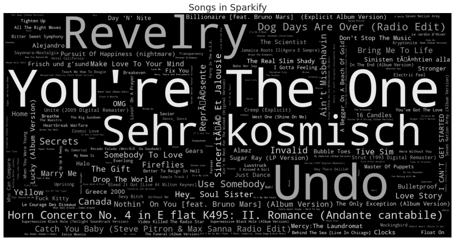

```python
# create a simple wordcloud with the song titles
songs_df = df.toPandas()["song"].value_counts().to_dict()

# create the figure and title
plt.figure(figsize=(16, 10))

# generate the wordcloud from frequencies
wc = WordCloud(width = 2000,
               height=1000,
               margin=10,
               random_state=1).generate_from_frequencies(songs_df)

# display the fitted and recolored wordcloud
plt.imshow(wc.recolor(color_func=grey_color_func, random_state=3),
           interpolation="bilinear")

# turn axis off to get rid of axis numbers
plt.axis("off")

# create title
plt.title("Songs in Sparkify")

# save to file
wc.to_file("images/sparkify_songs.png")

plt.show()
```

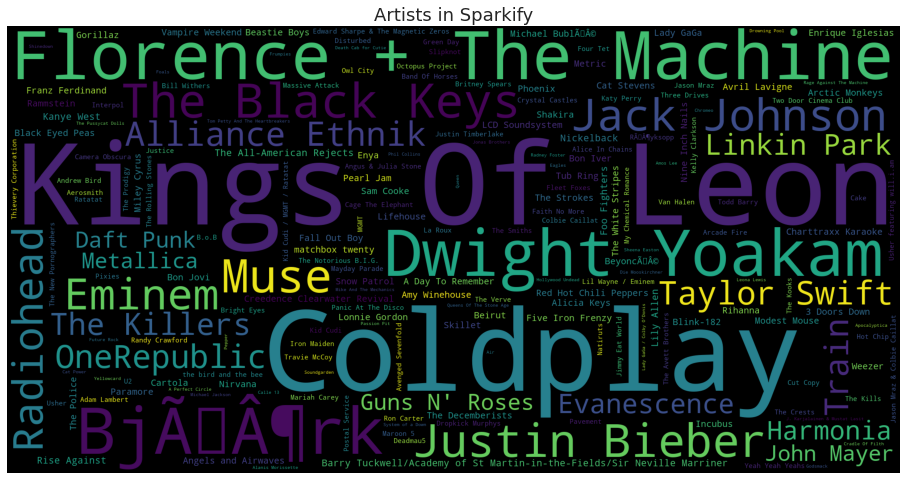

```python
# create a simple wordcloud with artist names
artists_df = df.toPandas()["artist"].value_counts().to_dict()

# create the figure and title
plt.figure(figsize=(16, 10))

# generate the wordcloud from frequencies
wc = WordCloud(width = 2000,
               height=1000,
               margin=10,
               random_state=1).generate_from_frequencies(artists_df)

# display the fitted wordcloud
plt.imshow(wc)

# turn axis off to get rid of axis numbers
plt.axis("off")

# create title
plt.title("Artists in Sparkify")

# save to file
wc.to_file("images/sparkify_artists.png")

plt.show()
```

```python
# take a look at the rows with missing song information
df.filter(df.song.isNull()).show(4)
```

```
+------+---------+---------+------+-------------+--------+------+-----+--------------------+------+---------------+-------------+---------+----+------+-------------+--------------------+------+--------------------+------+-------------------+-------------------+------+-------+----------+-----------+-…
|artist|     auth|firstName|gender|itemInSession|lastName|length|level|            location|method|           page| registration|sessionId|song|status|           ts|           userAgent|userId|                city| state|           event_ts|           date_reg|day_ts|day_reg|weekday_ts|weekday_reg|m…
+------+---------+---------+------+-------------+--------+------+-----+--------------------+------+---------------+-------------+---------+----+------+-------------+--------------------+------+--------------------+------+-------------------+-------------------+------+-------+----------+-----------+-…
|  null|Logged In|    Colin|     M|           54| Freeman|  null| paid|     Bakersfield, CA|   PUT|Add to Playlist|1538173362000|       29|null|   200|1538352905000|Mozilla/5.0 (Wind...|    30|         Bakersfield|    CA|2018-09-30 20:15:05|2018-09-28 18:22:42|    30|     28|    Sunday|     Friday| …
|  null|Logged In|    Micah|     M|           84|    Long|  null| free|Boston-Cambridge-...|   GET|    Roll Advert|1538331630000|        8|null|   200|1538353150000|"Mozilla/5.0 (Win...|     9|Boston-Cambridge-...| MA-NH|2018-09-30 20:19:10|2018-09-30 14:20:30|    30|     30|    Sunday|     Sunday| …
|  null|Logged In|    Micah|     M|           86|    Long|  null| free|Boston-Cambridge-...|   PUT|      Thumbs Up|1538331630000|        8|null|   307|1538353376000|"Mozilla/5.0 (Win...|     9|Boston-Cambridge-...| MA-NH|2018-09-30 20:22:56|2018-09-30 14:20:30|    30|     30|    Sunday|     Sunday| …
|  null|Logged In|    Alexi|     F|            4|  Warren|  null| paid|Spokane-Spokane V...|   GET|      Downgrade|1532482662000|       53|null|   200|1538354749000|Mozilla/5.0 (Wind...|    54|Spokane-Spokane V...|    WA|2018-09-30 20:45:49|2018-07-24 21:37:42|    30|     24|    Sunday|    Tuesday| …
+------+---------+---------+------+-------------+--------+------+-----+--------------------+------+---------------+-------------+---------+----+------+-------------+--------------------+------+--------------------+------+-------------------+-------------------+------+-------+----------+-----------+-…
only showing top 4 rows
```

The records are missing just the song information, while the user and log information is available.

### length Column

It represents the length of a song, in seconds.

```python
# print descriptive statistics for songs length
df.describe("length").show()
```

```
+-------+------------------+
|summary|            length|
+-------+------------------+
|  count|            228108|
|   mean|249.11718197783478|
| stddev| 99.23517921058324|
|    min|           0.78322|
|    max|        3024.66567|
+-------+------------------+
```

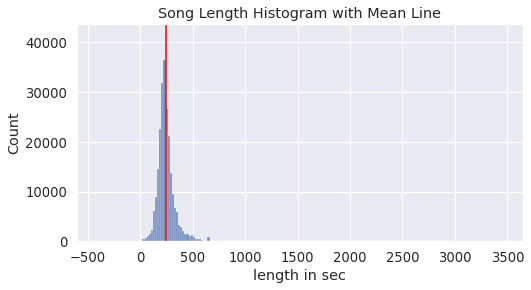

```python
# plot the distribution of song lengths

# adjust figure size and font size
sns.set(rc = {'figure.figsize':(8,4)})
sns.set(font_scale=1.2)

# pad margins so that markers don't get clipped by the axes
plt.margins(x=0.2, y=0.2, tight=True);

sns.histplot(data=df.toPandas(), x="length", binwidth=20);

# create vertical line to indicate the mean
plt.axvline(x=df.toPandas().length.mean(), color='red');

# create label axes
plt.xlabel("length in sec")

# create title
plt.title("Song Length Histogram with Mean Line");
```

```python
# count the number of songs longer than 1000 s (about 16 min)
df.filter(df["length"] > "1000").count()
```

```
282
```

### itemInSession Column

```python
# print descriptive statistics for itemInSession column
df.describe("itemInSession").show()
```

```
+-------+------------------+
|summary|     itemInSession|
+-------+------------------+
|  count|            286500|
|   mean|114.41421291448516|
| stddev|129.76726201141113|
|    min|                 0|
|    max|              1321|
+-------+------------------+
```

```python
# create a dataframe for those data points with itemInSession=0
itemInSession_zero = df.filter(df['itemInSession'] == 0)
# find how many entries have itemInSession = 0
itemInSession_zero.count()
```

```
3278
```

```python
# take a look at some of the data with 0 logs in session
itemInSession_zero.show(4)
```

```
+-----------------+----------+---------+------+-------------+--------+---------+-----+--------------------+------+--------+-------------+---------+--------------------+------+-------------+--------------------+------+--------------------+-----+-------------------+-------------------+------+-------+-…
|           artist|      auth|firstName|gender|itemInSession|lastName|   length|level|            location|method|    page| registration|sessionId|                song|status|           ts|           userAgent|userId|                city|state|           event_ts|           date_reg|day_ts|day_reg|w…
+-----------------+----------+---------+------+-------------+--------+---------+-----+--------------------+------+--------+-------------+---------+--------------------+------+-------------+--------------------+------+--------------------+-----+-------------------+-------------------+------+-------+-…
|Tokyo Police Club| Logged In|  Ashlynn|     F|            0|Williams| 166.1122| free|     Tallahassee, FL|   PUT|NextSong|1537365219000|      217|Citizens Of Tomorrow|   200|1538353668000|"Mozilla/5.0 (Mac...|    74|         Tallahassee|   FL|2018-09-30 20:27:48|2018-09-19 09:53:39|    30|     19| …
|            Modjo| Logged In|    Alexi|     F|            0|  Warren|250.93179| paid|Spokane-Spokane V...|   PUT|NextSong|1532482662000|       53|         What I Mean|   200|1538353930000|Mozilla/5.0 (Wind...|    54|Spokane-Spokane V...|   WA|2018-09-30 20:32:10|2018-07-24 21:37:42|    30|     24| …
|    Dwight Yoakam| Logged In|   Warren|     M|            0|  Miller| 239.3073| free|Baltimore-Columbi...|   PUT|NextSong|1538169823000|      240|      You're The One|   200|1538356650000|Mozilla/5.0 (Wind...|     4|Baltimore-Columbi...|   MD|2018-09-30 21:17:30|2018-09-28 17:23:43|    30|     28| …
|             null|Logged Out|     null|  null|            0|    null|     null| free|                null|   PUT|   Login|         null|      100|                null|   307|1538358102000|                null|      |                null| null|2018-09-30 21:41:42|               null|    30|   null| …
+-----------------+----------+---------+------+-------------+--------+---------+-----+--------------------+------+--------+-------------+---------+--------------------+------+-------------+--------------------+------+--------------------+-----+-------------------+-------------------+------+-------+-…
only showing top 4 rows
```

```python
# check for null values for the zero itemInSession rows
itemInSession_zero.select([count(when(isnan(c) | col(c).isNull(), c)) \
           .alias(c) for c in itemInSession_zero.columns]) \
           .show(vertical=True)
```

```
-RECORD 0-------------
 artist        | 1586
 auth          | 0
 firstName     | 589
 gender        | 589
 itemInSession | 0
 lastName      | 589
 length        | 1586
 level         | 0
 location      | 589
 method        | 0
 page          | 0
 registration  | 589
 sessionId     | 0
 song          | 1586
 status        | 0
 ts            | 0
 userAgent     | 589
 userId        | 0
 city          | 589
 state         | 589
 event_ts      | 0
 date_reg      | 589
 day_ts        | 0
 day_reg       | 589
 weekday_ts    | 0
 weekday_reg   | 589
 month_ts      | 0
 month_reg     | 589
 hour_ts       | 0
```

```python
itemInSession_zero.groupby("page").count().show()
```

```
+--------+-----+
|    page|count|
+--------+-----+
|    Home| 1352|
|   About|    6|
|   Login|  207|
|Register|    1|
|NextSong| 1692|
|    Help|   18|
|   Error|    2|
+--------+-----+
```

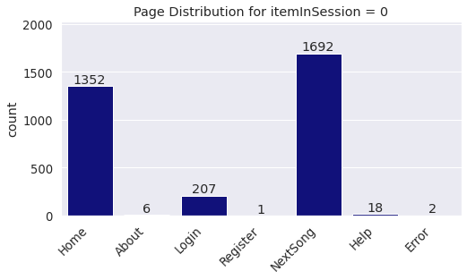

```python
# plot the page usage distribution for zero itemInSession

# create the count dataframe
itemInSession_page = itemInSession_zero.groupby("page").count().toPandas()

# adjust figure size and font size
sns.set(rc = {'figure.figsize':(8,4)})
sns.set(font_scale=1.2)

# pad margins so that markers don't get clipped by the axes
plt.margins(x=0.2, y=0.2, tight=True);

# create the plot
ax = sns.barplot(x="page", y="count",
            data=itemInSession_page,
           color="darkblue")

# create labels and title
ax.bar_label(ax.containers[0]);
plt.title("Page Distribution for itemInSession = 0");
ax.set(xlabel = None)
plt.xticks(rotation=45, horizontalalignment='right');
```

### userId Column

```python
# the distribution of sessions by userId
df.groupby("userId").count().show(6)
```

```
+------+-----+
|userId|count|
+------+-----+
|100010|  381|
|200002|  474|
|   125|   11|
|    51| 2464|
|   124| 4825|
|     7|  201|
+------+-----+
only showing top 6 rows
```

```python
# there are no null values in userId
df.where(col("userId").isNull()).count()
```

```
0
```

```python
# sample of information available for sessions for user 125
df.where(df.userId == "125").select("sessionId", "event_ts", "date_reg", "page").show(20)
```

```
+---------+-------------------+-------------------+--------------------+
|sessionId|           event_ts|           date_reg|                page|
+---------+-------------------+-------------------+--------------------+
|      174|2018-10-12 00:05:44|2018-08-01 16:58:59|            NextSong|
|      174|2018-10-12 00:11:21|2018-08-01 16:58:59|            NextSong|
|      174|2018-10-12 00:15:11|2018-08-01 16:58:59|            NextSong|
|      174|2018-10-12 00:18:34|2018-08-01 16:58:59|            NextSong|
|      174|2018-10-12 00:22:04|2018-08-01 16:58:59|            NextSong|
|      174|2018-10-12 00:28:35|2018-08-01 16:58:59|            NextSong|
|      174|2018-10-12 00:32:08|2018-08-01 16:58:59|            NextSong|
|      174|2018-10-12 00:35:06|2018-08-01 16:58:59|            NextSong|
|      174|2018-10-12 00:35:17|2018-08-01 16:58:59|         Roll Advert|
|      174|2018-10-12 00:35:18|2018-08-01 16:58:59|              Cancel|
|      174|2018-10-12 00:35:18|2018-08-01 16:58:59|Cancellation Conf...|
+---------+-------------------+-------------------+--------------------+
```

### sessionId Column

```python
# the distribution of sessions by userId
df.groupby("sessionId","userId").count().show(6)
```

```
+---------+------+-----+
|sessionId|userId|count|
+---------+------+-----+
|      360|    18|   32|
|      389|    59|    1|
|      281|      |   14|
|      446|      |    4|
|      769|    42|  257|
|      456|      |    1|
+---------+------+-----+
only showing top 6 rows
```

```python
# count distinct userId per session Id
df_sessions = df.groupBy("userId", "sessionId").count().orderBy("count", ascending=False)
# sessions with more than one user - note this does not happen simultaneously
df_sessions.where(df_sessions["count"] != 1).show(10)
```

```
+------+---------+-----+
|userId|sessionId|count|
+------+---------+-----+
|    91|     1840| 1282|
|   115|      316| 1080|
|   101|      635|  855|
|   120|      731|  758|
|   138|     2305|  699|
|    25|      827|  695|
|300002|      436|  676|
|    23|     2056|  668|
|   140|     1483|  656|
|    41|      377|  645|
+------+---------+-----+
only showing top 10 rows
```

```python
# the distribution of sessions by userId
df.groupby("sessionId","userId").count().orderBy("sessionId", ascending=True).show(6)
```

```
+---------+------+-----+
|sessionId|userId|count|
+---------+------+-----+
|        1|      |   34|
|        1|100001|   51|
|        1|300001|  201|
|        1|     2|  428|
|        2|200002|    7|
|        3|100003|    2|
+---------+------+-----+
only showing top 6 rows
```

```python
# example of a sessionId with more than one user associated to it
df.where(df.sessionId=="3").select("userId", "page", "event_ts").show(6)
```

```
+------+--------+-------------------+
|userId|    page|           event_ts|
+------+--------+-------------------+
|100003|NextSong|2018-10-09 11:53:40|
|100003|NextSong|2018-10-09 11:56:53|
|300003|NextSong|2018-10-12 10:54:57|
|300003|NextSong|2018-10-12 10:58:19|
|300003|NextSong|2018-10-12 11:02:51|
|300003|NextSong|2018-10-12 11:05:54|
+------+--------+-------------------+
only showing top 6 rows
```

## Clean the Data

```python
# filter out all the rows that have empty userId
df_clean = df.filter(df.userId != "")
```

```python
# check for null values
df_clean.select([count(when(isnan(c) | col(c).isNull(), c)) \
           .alias(c) for c in df.columns]) \
           .show(vertical=True)
```

```
[Stage 254:====>                                                  (1 + 11) / 12]
```

```
-RECORD 0--------------
 artist        | 50046
 auth          | 0
 firstName     | 0
 gender        | 0
 itemInSession | 0
 lastName      | 0
 length        | 50046
 level         | 0
 location      | 0
 method        | 0
 page          | 0
 registration  | 0
 sessionId     | 0
 song          | 50046
 status        | 0
 ts            | 0
 userAgent     | 0
 userId        | 0
 city          | 0
 state         | 0
 event_ts      | 0
 date_reg      | 0
 day_ts        | 0
 day_reg       | 0
 weekday_ts    | 0
 weekday_reg   | 0
 month_ts      | 0
 month_reg     | 0
 hour_ts       | 0
```

## Refactor Code: Load and Clean Data

```python
# load the data
file_path = "data/mini_sparkify_event_data.json"

def load_data(file_path):

    print("Loading the dataset ...")
    df = spark.read.json(file_path)

    return df

def clean_data(df):

    # print message to indicate the start of the process
    print("Cleaning the data ...")

    # print a count of rows before cleaning
    initial_records = df.count()
    print("Dataset has {} rows initially.".format(initial_records))

    # filter out all the records without userId
    df = df.filter(df.userId != "")

    # split the location column in two columns: city and state
    df = df.withColumn("city", split(df["location"], ",").getItem(0)) \
           .withColumn("state", split(df["location"], ",").getItem(1))

    # drop the location column
    df.drop(df.location)

    # parse the timestamp columns: registration and ts
    df = df.withColumn("date_ts", from_unixtime(col("ts")/1000.0))
    df = df.withColumn("date_reg", from_unixtime(col("registration")/1000.0))

    # print end of process message
    print("Finished cleaning the data ...")

    # print a count of rows after cleaning
    removed_rows = initial_records - df.count()
    print("Cleaned dataset has {} rows, {} rows were removed". \
        format(df.count(), initial_records - df.count()))

    return df
```

```python
df_new=load_data(file_path)
```

```
Loading the dataset ...
```

```python
df_new = clean_data(df_new)
```

```
Cleaning the data ...
Dataset has 286500 rows initially.
Finished cleaning the data ...
Cleaned dataset has 278154 rows, 8346 rows were removed
```